# Pertemuan 5_MPDW

Syifa Khairunnisa

2023-09-26

```r
library(ggplot2)
library(tsibble)
library(tseries)
library(MASS)
library(rio)
stas <- import("https://raw.githubusercontent.com/syifaskn/MPDWPraktikum/main/Pertemuan%205/DataTempSulsel.csv")
stas
```

```
##       Time MaxTemp
## 1   Mar-10   30.19
## 2   Apr-10   30.30
## 3   May-10   30.35
## 4   Jun-10   30.28
## 5   Jul-10   30.05
## 6   Aug-10   30.49
## 7   Sep-10   30.88
## 8   Oct-10   31.42
## 9   Nov-10   31.36
## 10  Dec-10   30.48
## 11  Jan-11   29.71
## 12  Feb-11   29.86
## 13  Mar-11   30.32
## 14  Apr-11   30.26
```

[output cut: 116 more lines]

mengubah data agar terbaca sebagai data deret waktu dengan fungsi `ts()`

```r
stas.ts <- ts(stas$MaxTemp)
```

## Plot *Time Series*

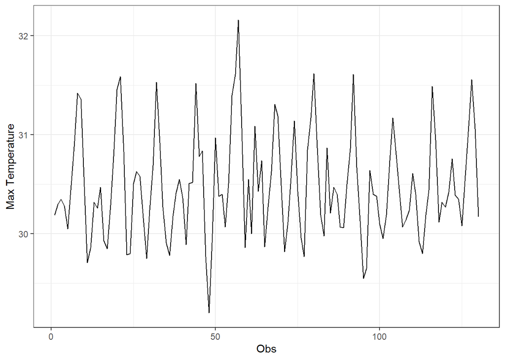

```r
plot_stas <- stas.ts |> as_tsibble() |>
  ggplot(aes(x = index, y = value)) + geom_line() + theme_bw() +
  xlab("Obs") + ylab("Max Temperature")
plot_stas
```

```r
mean(stas.ts)
```

```
## [1] 30.484
```

Plot deret waktu di atas menunjukkan bahwa data stasioner dalam rataan, ditandai dengan data yang menyebar di sekitar nilai tengahnya (30.484) dan stasioner dalam ragam, ditandai dengan lebar pita yang cenderung sama.

### Plot ACF

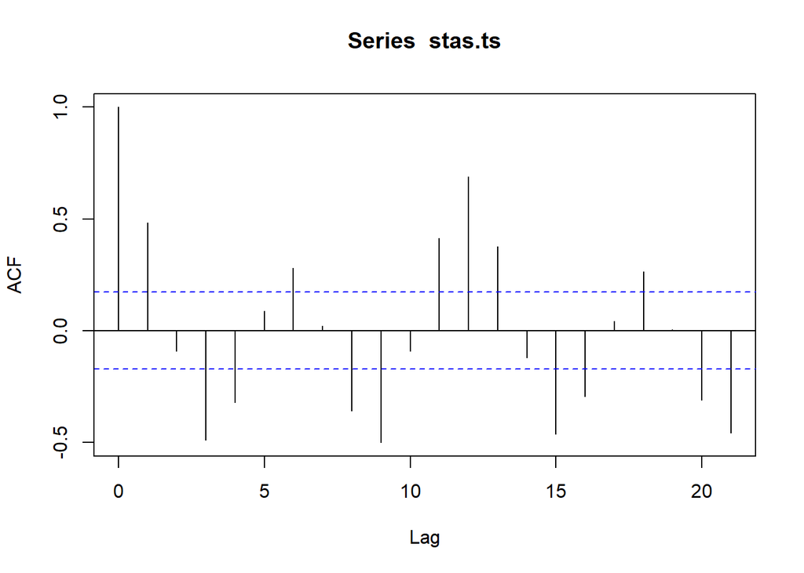

```r
acf(stas.ts)
```

Berdasarkan plot ACF, terlihat bahwa plot ACF pada data tersebut cenderung *tails off* dan membentuk gelombang sinus.

### Uji ADF

```r
tseries::adf.test(stas.ts)
```

```
##
##  Augmented Dickey-Fuller Test
##
## data:  stas.ts
## Dickey-Fuller = -4.8072, Lag order = 5, p-value = 0.01
## alternative hypothesis: stationary
```

$H_0$ : Data tidak stasioner dalam rataan

$H_1$ : Data stasioner dalam rataan

Berdasarkan uji ADF tersebut, didapat *p-value* sebesar 0.01 yang lebih kecil dari taraf nyata 5% sehingga tolak $H_0$ dan menandakan bahwa data stasioner dalam rataan. Hal ini sesuai dengan hasil eksplorasi menggunakan plot time series dan plot ACF.

### Plot Box-Cox

** uji box cox ga bisa kalau misal ada nilai amatan yang negatif

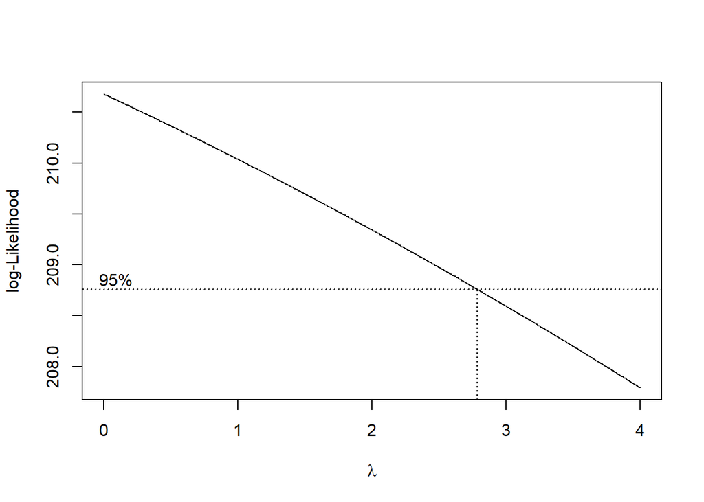

```r
index <- seq(1:130) #dibuat sesuai banyak amatan
bc = boxcox(stas.ts~index, lambda = seq(0,4,by=0.01))
```

```r
#Nilai Rounded Lambda
lambda <- bc$x[which.max(bc$y)]
lambda
```

```
## [1] 0
```

```r
#SK
bc$x[bc$y > max(bc$y) - 1/2 * qchisq(.95,1)]
```

```
##   [1] 0.00 0.01 0.02 0.03 0.04 0.05 0.06 0.07 0.08 0.09 0.10 0.11 0.12 0.13 0.14
##  [16] 0.15 0.16 0.17 0.18 0.19 0.20 0.21 0.22 0.23 0.24 0.25 0.26 0.27 0.28 0.29
##  [31] 0.30 0.31 0.32 0.33 0.34 0.35 0.36 0.37 0.38 0.39 0.40 0.41 0.42 0.43 0.44
##  [46] 0.45 0.46 0.47 0.48 0.49 0.50 0.51 0.52 0.53 0.54 0.55 0.56 0.57 0.58 0.59
##  [61] 0.60 0.61 0.62 0.63 0.64 0.65 0.66 0.67 0.68 0.69 0.70 0.71 0.72 0.73 0.74
##  [76] 0.75 0.76 0.77 0.78 0.79 0.80 0.81 0.82 0.83 0.84 0.85 0.86 0.87 0.88 0.89
##  [91] 0.90 0.91 0.92 0.93 0.94 0.95 0.96 0.97 0.98 0.99 1.00 1.01 1.02 1.03 1.04
## [106] 1.05 1.06 1.07 1.08 1.09 1.10 1.11 1.12 1.13 1.14 1.15 1.16 1.17 1.18 1.19
## [121] 1.20 1.21 1.22 1.23 1.24 1.25 1.26 1.27 1.28 1.29 1.30 1.31 1.32 1.33 1.34
## [136] 1.35 1.36 1.37 1.38 1.39 1.40 1.41 1.42 1.43 1.44 1.45 1.46 1.47 1.48 1.49
## [151] 1.50 1.51 1.52 1.53 1.54 1.55 1.56 1.57 1.58 1.59 1.60 1.61 1.62 1.63 1.64
## [166] 1.65 1.66 1.67 1.68 1.69 1.70 1.71 1.72 1.73 1.74 1.75 1.76 1.77 1.78 1.79
## [181] 1.80 1.81 1.82 1.83 1.84 1.85 1.86 1.87 1.88 1.89 1.90 1.91 1.92 1.93 1.94
## [196] 1.95 1.96 1.97 1.98 1.99 2.00 2.01 2.02 2.03 2.04 2.05 2.06 2.07 2.08 2.09
## [211] 2.10 2.11 2.12 2.13 2.14 2.15 2.16 2.17 2.18 2.19 2.20 2.21 2.22 2.23 2.24
## [226] 2.25 2.26 2.27 2.28 2.29 2.30 2.31 2.32 2.33 2.34 2.35 2.36 2.37 2.38 2.39
## [241] 2.40 2.41 2.42 2.43 2.44 2.45 2.46 2.47 2.48 2.49 2.50 2.51 2.52 2.53 2.54
## [256] 2.55 2.56 2.57 2.58 2.59 2.60 2.61 2.62 2.63 2.64 2.65 2.66 2.67 2.68 2.69
## [271] 2.70 2.71 2.72 2.73 2.74 2.75 2.76 2.77 2.78
```

Gambar di atas menunjukkan nilai *rounded value* ($\lambda$) optimum sebesar **0** dan pada selang kepercayaan 95% nilai memiliki batas bawah **0** dan batas atas **2.78**. Selang tersebut memuat nilai satu sehingga dapat dikatakan bahwa data stasioner dalam ragam.

### Partisi Data

#### Bagian 1

```r
dt_stas1 <- stas.ts[1:85] |> ts()
mean(dt_stas1)
```

```
## [1] 30.50353
```

```r
var(dt_stas1)
```

```
## [1] 0.3231564
```

#### Plot Time Series

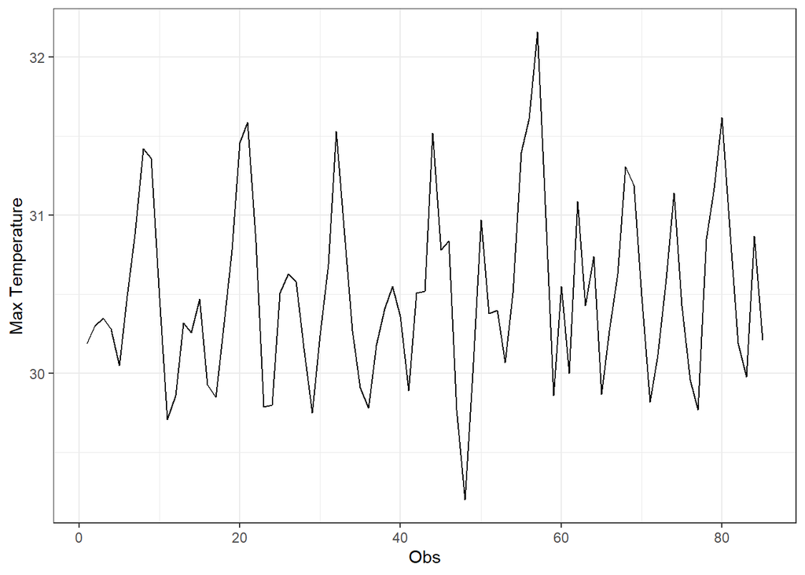

```r
dt_stas1 |> as_tsibble() |>
  ggplot(aes(x = index, y = value)) +
  geom_line() + theme_bw() +
  xlab("Obs") + ylab("Max Temperature")
```

Plot deret waktu di atas menunjukkan bahwa data stasioner dalam rataan, ditandai dengan data yang menyebar di sekitar nilai tengahnya (30-an) dan stasioner dalam ragam, ditandai dengan lebar pita yang cenderung sama.

#### Plot ACF

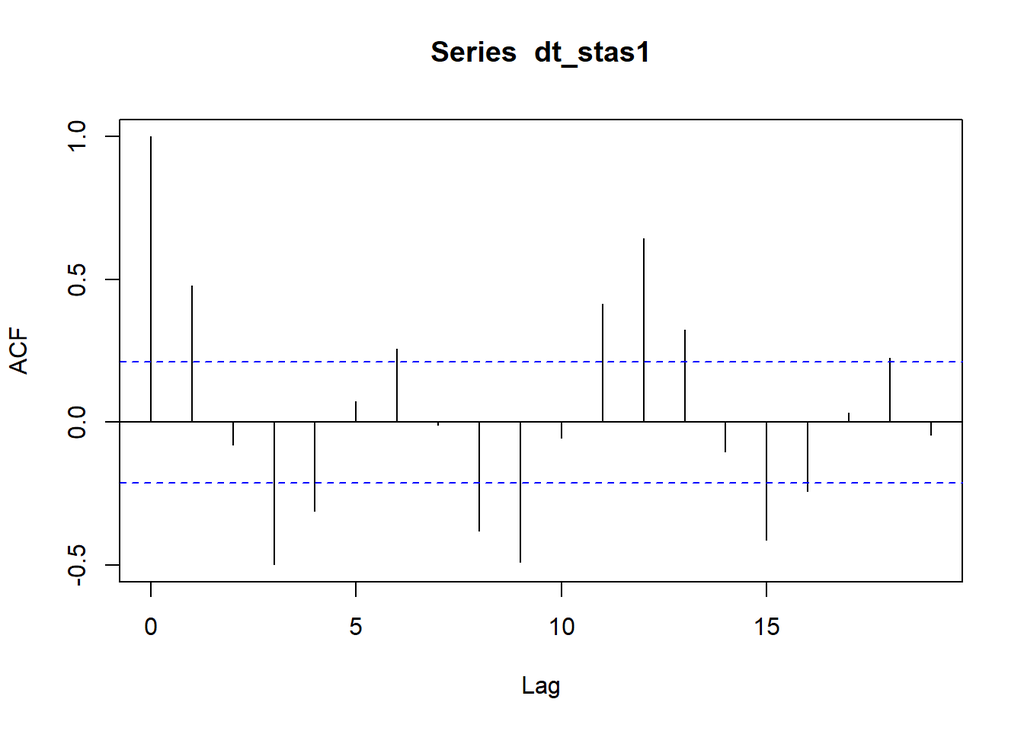

```r
acf(dt_stas1)
```

Berdasarkan plot ACF, terlihat bahwa plot ACF pada data tersebut cenderung *tails off* dan membentuk gelombang sinus.

#### Uji ADF

```r
tseries::adf.test(dt_stas1)
```

```
##
##  Augmented Dickey-Fuller Test
##
## data:  dt_stas1
## Dickey-Fuller = -3.7188, Lag order = 4, p-value = 0.02794
## alternative hypothesis: stationary
```

$H_0$ : Data tidak stasioner dalam rataan

$H_1$ : Data stasioner dalam rataan

Berdasarkan uji ADF tersebut, didapat *p-value* sebesar 0.02794 yang lebih kecil dari taraf nyata 5% sehingga tolak $H_0$ dan menandakan bahwa data stasioner dalam rataan. Hal ini sesuai dengan hasil eksplorasi menggunakan plot time series dan plot ACF.

#### Plot Boxcox

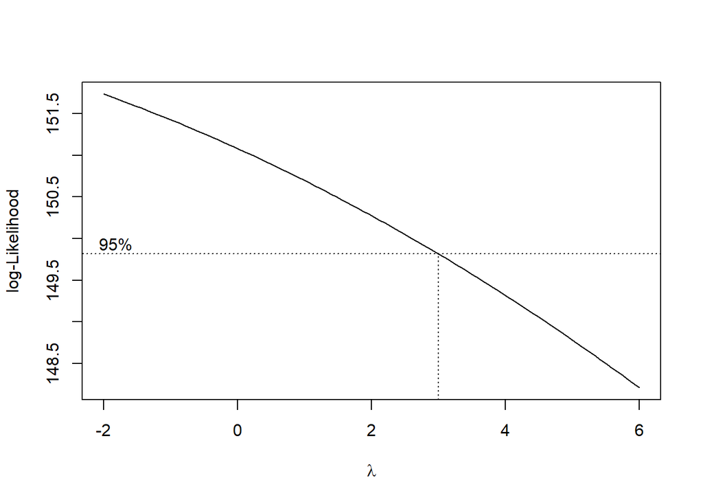

```r
index <- seq(1:85)
bc = boxcox(dt_stas1~index, lambda = seq(-2,6,by=1))
```

```r
#Nilai Rounded Lambda
lambda <- bc$x[which.max(bc$y)]
lambda
```

```
## [1] -2
```

```r
#SK
bc$x[bc$y > max(bc$y) - 1/2 * qchisq(.95,1)]
```

```
##  [1] -2.00000000 -1.91919192 -1.83838384 -1.75757576 -1.67676768 -1.59595960
##  [7] -1.51515152 -1.43434343 -1.35353535 -1.27272727 -1.19191919 -1.11111111
## [13] -1.03030303 -0.94949495 -0.86868687 -0.78787879 -0.70707071 -0.62626263
## [19] -0.54545455 -0.46464646 -0.38383838 -0.30303030 -0.22222222 -0.14141414
## [25] -0.06060606  0.02020202  0.10101010  0.18181818  0.26262626  0.34343434
## [31]  0.42424242  0.50505051  0.58585859  0.66666667  0.74747475  0.82828283
## [37]  0.90909091  0.98989899  1.07070707  1.15151515  1.23232323  1.31313131
## [43]  1.39393939  1.47474747  1.55555556  1.63636364  1.71717172  1.79797980
## [49]  1.87878788  1.95959596  2.04040404  2.12121212  2.20202020  2.28282828
## [55]  2.36363636  2.44444444  2.52525253  2.60606061  2.68686869  2.76767677
## [61]  2.84848485  2.92929293
```

Gambar di atas menunjukkan nilai *rounded value* ($\lambda$) optimum sebesar **-2** dan pada selang kepercayaan 95% nilai memiliki batas bawah **-2** dan batas atas **2.92929293**. Selang tersebut memuat nilai satu sehingga dapat dikatakan bahwa data bangkitan stasioner dalam ragam.

#### Bagian 2

```r
dt_stas2 <- stas.ts[86:130] |> ts()
mean(dt_stas2)
```

```
## [1] 30.44711
```

```r
var(dt_stas2)
```

```
## [1] 0.2155892
```

#### Plot Time Series

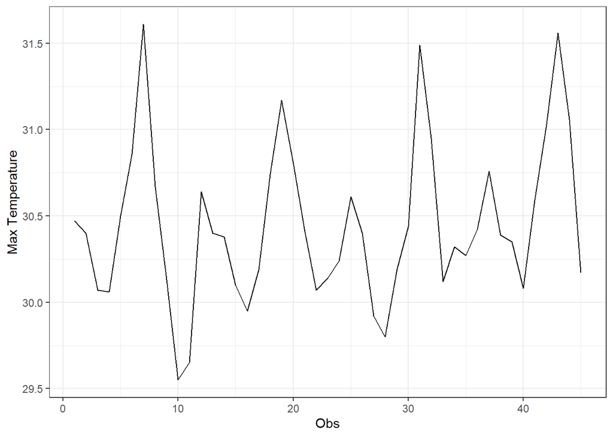

```r
dt_stas2 |> as_tsibble() |>
  ggplot(aes(x = index, y = value)) +
  geom_line() + theme_bw() +
  xlab("Obs") + ylab("Max Temperature")
```

Plot deret waktu di atas menunjukkan bahwa data stasioner dalam rataan, ditandai dengan data yang menyebar di sekitar nilai tengahnya (30-an) dan stasioner dalam ragam, ditandai dengan lebar pita yang cenderung sama.

#### Plot ACF

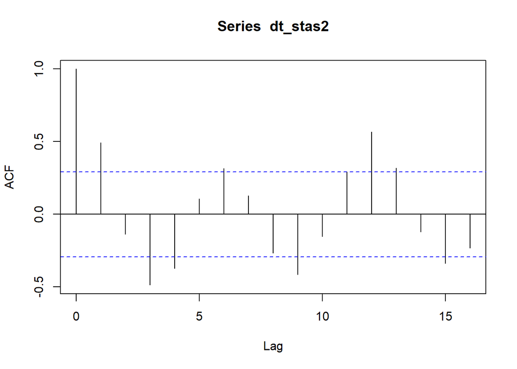

```r
acf(dt_stas2)
```

Berdasarkan plot ACF, terlihat bahwa plot ACF pada data tersebut cenderung *tails off* dan membentuk gelombang sinus.

#### Uji ADF

```r
adf.test(dt_stas2)
```

```
##
##  Augmented Dickey-Fuller Test
##
## data:  dt_stas2
## Dickey-Fuller = -4.1888, Lag order = 3, p-value = 0.01066
## alternative hypothesis: stationary
```

$H_0$ : Data tidak stasioner dalam rataan

$H_1$ : Data stasioner dalam rataan

Berdasarkan uji ADF tersebut, didapat *p-value* sebesar 0.01066 yang lebih kecil dari taraf nyata 5% sehingga tolak $H_0$ dan menandakan bahwa data stasioner dalam rataan. Hal ini sesuai dengan hasil eksplorasi menggunakan plot time series dan plot ACF.

#### Plot Boxcox

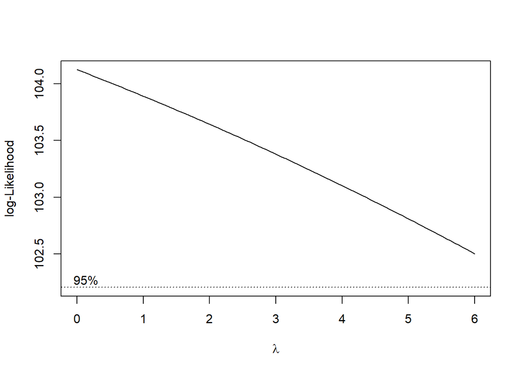

```r
index <- seq(86:130)
bc = boxcox(dt_stas2~index, lambda = seq(0,6,by=1))
```

```r
#Nilai Rounded Lambda
lambda <- bc$x[which.max(bc$y)]
lambda
```

```
## [1] 0
```

```r
#SK
bc$x[bc$y > max(bc$y) - 1/2 * qchisq(.95,1)]
```

```
##   [1] 0.00000000 0.06060606 0.12121212 0.18181818 0.24242424 0.30303030
##   [7] 0.36363636 0.42424242 0.48484848 0.54545455 0.60606061 0.66666667
##  [13] 0.72727273 0.78787879 0.84848485 0.90909091 0.96969697 1.03030303
##  [19] 1.09090909 1.15151515 1.21212121 1.27272727 1.33333333 1.39393939
##  [25] 1.45454545 1.51515152 1.57575758 1.63636364 1.69696970 1.75757576
##  [31] 1.81818182 1.87878788 1.93939394 2.00000000 2.06060606 2.12121212
##  [37] 2.18181818 2.24242424 2.30303030 2.36363636 2.42424242 2.48484848
##  [43] 2.54545455 2.60606061 2.66666667 2.72727273 2.78787879 2.84848485
##  [49] 2.90909091 2.96969697 3.03030303 3.09090909 3.15151515 3.21212121
##  [55] 3.27272727 3.33333333 3.39393939 3.45454545 3.51515152 3.57575758
##  [61] 3.63636364 3.69696970 3.75757576 3.81818182 3.87878788 3.93939394
##  [67] 4.00000000 4.06060606 4.12121212 4.18181818 4.24242424 4.30303030
##  [73] 4.36363636 4.42424242 4.48484848 4.54545455 4.60606061 4.66666667
##  [79] 4.72727273 4.78787879 4.84848485 4.90909091 4.96969697 5.03030303
##  [85] 5.09090909 5.15151515 5.21212121 5.27272727 5.33333333 5.39393939
##  [91] 5.45454545 5.51515152 5.57575758 5.63636364 5.69696970 5.75757576
##  [97] 5.81818182 5.87878788 5.93939394 6.00000000
```

Gambar di atas menunjukkan nilai *rounded value* ($\lambda$) optimum sebesar **0** dan pada selang kepercayaan 95% nilai memiliki batas bawah **0** dan batas atas **6**. Selang tersebut memuat nilai satu sehingga dapat dikatakan bahwa data bangkitan stasioner dalam ragam.

# Kesimpulan

**Data Max Temperature Sulsel ini merupakan data yang stasioner dalam rataan dan ragam**, baik secara keseluruhan data maupun saat dibagi menjadi dua partisi data. Hal ini ditunjukkan oleh plot ACF yang cenderung *tails off* dan membentuk gelombang sinus dan keputusan uji ADF yang tolak $H_0$ sehingga menandakan bahwa data tersebut stasioner dalam rataan. Selain itu, plot Box-Cox menunjukkan rounded value dengan selang kepercayaan 95% memuat nilai satu sehingga dapat dikatakan bahwa data bangkitan stasioner dalam ragam.